# Day 1: R basics and data cleaning

Skip to the lesson

SMART TOOLSEcology with R and AI

DAY 01

R basics  
and data cleaning

0 of 8 steps checked

Check off each step as you go.  
Progress stays in this browser.

SMART TOOLS Day 1 · R basics

# Day 1: R basics and data cleaning

Mohan Bi

Smart Tools · Ecology with R and AI

Today you will use a real soil dataset to investigate a concrete ecological question. Work through the steps in RStudio, save your commands in a script, and explain your first figure in your own words.

Beginner level · About 3 hours, including a break · Guided practical

Download the student files ↓ Dataset only Starter R script

This page is your guide. Run the R commands in RStudio on your computer. The buttons copy code; they do not run R in this page.

## 0. Our question and today’s goal

**Does soil exposed to drought have a different proportion of water-stable aggregates from control soil?**

Soil aggregates are groups of soil particles. Their stability matters for soil structure and its functions. Here we use the proportion of **water-stable aggregates (`WSA`)** as a measurement of aggregate stability. A higher value means a larger proportion remained stable during the measurement. In this dataset, WSA is recorded as a fraction: `0.60` corresponds to `60%`.

We will compare `CT` (control) with `D` (drought applied alone). Other treatments remain in the original dataset for later course days. Today we describe the observations. We will investigate statistical tests and uncertainty on Day 2.

**Before looking at the data:** write one sentence in a comment in your R script. Do you expect drought to increase, decrease, or leave WSA unchanged? Give a possible ecological reason. A prediction can be useful even when the data later disagree with it.

```r
# My prediction: ...
# My ecological reason: ...
```

By the end, you should be able to:

- Import a CSV and explain what its rows and columns represent.
- Select the observations needed for an ecological question.
- Identify missing values and document how they affect a particular analysis.
- Create a figure, describe the pattern, and save a script that runs again.

**Today’s route and suggested timing**

| Part | Main task | Minutes |
| --- | --- | --- |
| 1 | Set up your project and script | 15 |
| 2 | Learn the R building blocks we need | 20 |
| 3 | Import and inspect the soil data | 20 |
| 4 | Select and combine treatment groups | 25 |
| 5 | Check types and missing values | 25 |
| Break | Pause before making the figure | 15 |
| 6 | Plot and describe control versus drought | 25 |
| 7 | Save the results and rerun your script | 20 |
| 8 | Complete the final checkpoint | 15 |
|  | **Total** | **180** |

The optional sections are for students who finish the core tasks early. You do not need to memorize every command.

## 1. Set up a place for your work

**Purpose:** keep your data, code, and outputs together so that you can repeat your work.

1. Download and unzip **the student files** above. Open the extracted folder, not the ZIP file.
2. Double-click `ABV_Day1.Rproj` to open the folder as an RStudio Project. If your computer asks, choose RStudio.
3. Open `Day1_starter.R`. Write your name and prediction at the top, then save it.
4. Check that `MultiFactor_data.csv` is in the same folder as the project and script.

Use the **script editor** to keep your commands. To run a line or selected lines, use **Ctrl + Enter** on Windows/Linux or **Cmd + Enter** on macOS. The **Console** shows the result; the **Environment** lists objects you create; **Plots** shows figures.

```r
getwd()
list.files()
file.exists("MultiFactor_data.csv")
```

**Do:** run the three commands from your script. Find the dataset in the file list.

**Check: is my setup ready?**

`file.exists("MultiFactor_data.csv")` should return `TRUE`. The exact path printed by `getwd()` depends on your computer. If the check returns `FALSE`, open the project inside the extracted folder and check the filename. Do not change the code to somebody else’s absolute path.

We will use base R for importing and preparing data, and `ggplot2` for the figure. If `ggplot2` is not installed, run this **once in the Console**. Installation requires an internet connection and may take a few minutes. Ask for help if it fails.

```r
install.packages("ggplot2")
```

Load it each time you start a fresh R session:

```r
library(ggplot2)
```

My project is open, the data file is found, and my script is saved.

## 2. Learn the R building blocks we need

**Purpose:** understand a small set of commands before using them on the soil data.

An **object** stores something under a name. The assignment operator `<-` means “store the value on the right under the name on the left.” A **function** performs an operation, and its **arguments** provide inputs or options.

```r
sample_count <- 4
sample_count

# A vector is a collection of values. These are invented practice values.
practice_wsa <- c(0.40, 0.50, 0.60, 0.70)
mean(practice_wsa)
length(practice_wsa)
```

**Do:** before running `mean(practice_wsa)`, calculate or predict its output. Then create a new vector called `my_wsa` with three invented WSA values and calculate its mean. Keep the values between 0 and 1.

**Check your first results**

The mean of `practice_wsa` is `0.55`, and its length is `4`. Your own vector will have a different mean, but `length(my_wsa)` should return `3`. If R prints `object ... not found`, first check that you ran the assignment and used the same capitalization.

R can also ask whether a condition is true:

```r
practice_wsa > 0.50
practice_wsa[practice_wsa > 0.50]
```

**Do:** change `>` to `>=`. Explain which extra observation is included. In R, `==` asks whether values are equal; `<-` assigns a value. Text, such as a treatment name, goes inside straight quotes: `"CT"`.

**Check: what do the square brackets do?**

`practice_wsa > 0.50` gives `FALSE FALSE TRUE TRUE`. Square brackets use those answers to keep `0.60` and `0.70`. With `>=`, `0.50` is included too. Later we will use the same idea to select treatment rows.

**Useful habit:** write a short comment beginning with `#` above a block of commands to explain its purpose. Use `?mean` to open help for a function.

I can create an object, call a function, and explain a logical comparison.

## 3. Import and inspect the soil dataset

**Purpose:** understand what you loaded before doing calculations.

```r
soil_data <- read.csv("MultiFactor_data.csv")

head(soil_data)
dim(soil_data)
names(soil_data)
str(soil_data)
```

`soil_data` is a **data frame**: rows are observations, and columns are variables measured or recorded for them. Here a row records a soil experimental unit. Multiple measurements in a row describe that same unit; they are not additional independent replicates.

Focus on these columns today:

| Column | Meaning | What to notice |
| --- | --- | --- |
| `remark` | Treatment label | `CT` = control; `D` = drought alone |
| `WSA` | Proportion of water-stable aggregates | Fraction between 0 and 1; our main response |
| `Decom` | Litter decomposition measurement | Proportional litter mass loss during incubation |
| `PH` | Soil pH | A numerical soil property |
| `Lv` | Number of applied global change factors | `0` = control; `1` = one factor |
| `D` | Indicator for whether drought is present | `1` also occurs in combinations with other factors |

The column names are case-sensitive: use `PH`, not `pH`. The leading `X` column is an exported index; it is not a soil property. The file contains other factor indicators and enzyme measurements that we will use later.

```r
summary(soil_data$WSA)
unique(soil_data$remark)
```

`$` extracts a column by name. For example, `soil_data$WSA` is the vector of WSA measurements inside the data frame.

**Do:** record the number of rows and columns in a comment. Explain `soil_data$WSA` to your neighbour, then inspect `soil_data$PH` using `summary()`.

**Check: what should I have loaded?**

The supplied course file has **353 rows and 23 columns**. `head()` displays the first six rows by default; it does not mean there are only six observations. `str()` reports the structure and types of the columns. `summary()` reports numerical summaries and, when present, the number of missing values.

I can explain a row, a column, and the response variable for our question.

## 4. Select and combine the groups we need

**Purpose:** make a dataset that matches the control–drought question.

```r
control_data <- soil_data[soil_data$remark == "CT", ]
drought_data <- soil_data[soil_data$remark == "D", ]

nrow(control_data)
nrow(drought_data)
```

Read the first line as: “From `soil_data`, keep rows whose `remark` equals `CT`, and keep all columns.” Inside `[rows, columns]`, the comma separates the two choices. Leaving the column position empty keeps every column.

**Do:** explain why we selected `remark == "D"` rather than `D == 1`. Check your answer using the data dictionary above.

**Check the selection and sample sizes**

You should have **20 control rows and 7 drought-only rows** in this course file. `D == 1` would also include rows where drought was combined with other factors. That would answer a different question. Use the observed sample sizes in the supplied file; do not assume equal group sizes.

Combine the selected rows, then retain the columns needed for today’s work:

```r
day1_data <- rbind(control_data, drought_data)
day1_data <- day1_data[, c("remark", "WSA", "Decom", "PH")]

table(day1_data$remark)
nrow(day1_data)
names(day1_data)
```

`rbind()` stacks rows from data frames with matching columns. It does not calculate group averages. We select columns by name so that the code stays readable if their order changes.

**Do:** check that only `CT` and `D` remain. In a comment, explain why there are 27 rows rather than 353. The original `soil_data` object has not been overwritten.

**Optional: the same selection using dplyr**

Only try this after you finish the main exercise. It is an alternative route to the same selected rows, not an extra required step. It needs the `dplyr` package.

```r
library(dplyr)
day1_alternative <- soil_data %>%
  filter(remark %in% c("CT", "D")) %>%
  select(remark, WSA, Decom, PH)
```

The pipe `%>%` passes the result of one operation into the next. Keep using the main `day1_data` object in the remaining steps.

My selected dataset contains 20 control and 7 drought observations.

## 5. Check data types and missing values

**Purpose:** make explicit decisions about the variables used in our question.

### 5.1 Identify the variable types

`remark` identifies categories, while `WSA` contains numerical measurements. A **factor** is R’s way of representing categories. Set the order explicitly so that control appears before drought in the figure:

```r
day1_data$remark <- factor(day1_data$remark, levels = c("CT", "D"))
str(day1_data)
```

**Do:** identify the categorical column and the numerical response in the output. Explain why calculating a mean of the treatment names would not make sense.

### 5.2 Count missing values before making a decision

`NA` means a value is missing or unavailable. It does not mean zero.

```r
sum(is.na(day1_data$WSA))
sum(is.na(soil_data$WSA))
```

**Do:** compare the selected dataset with the full dataset. Do both have missing WSA measurements?

**Check the missing-value counts**

There are **0 missing WSA values in the control–drought subset** and **6 in the full dataset**. We will still document a response-specific decision, so that the workflow also works when another treatment or response has missing measurements.

### 5.3 See what a missing value does

This next vector is an **invented teaching example**, not a modification of the real soil data:

```r
practice_missing <- c(0.50, NA, 0.70)
mean(practice_missing)
mean(practice_missing, na.rm = TRUE)
sum(!is.na(practice_missing))
```

**Do:** explain why the first mean is `NA`. How many measured observations support the second mean?

**Check: does na.rm fill in the missing value?**

The first calculation returns `NA`. With `na.rm = TRUE`, R calculates the mean of the **two observed values**, giving `0.60`. It does not fill in the missing value or recover a lost measurement. Check why data are missing and report the number used in your analysis.

### 5.4 Prepare a dataset for the WSA figure

```r
day1_wsa <- day1_data[!is.na(day1_data$WSA), ]

nrow(day1_data) - nrow(day1_wsa)
table(day1_wsa$remark)
```

`!` means “not.” This keeps rows where WSA is observed, while keeping all columns. For today’s selected groups, no rows are removed. A row with a missing WSA value would be unavailable for this WSA comparison; it could still be useful for a different response. Keep the original data and document your decision.

**A cleaning decision to discuss:** the following commands count rows retained under two different rules. They do not overwrite the data.

```r
sum(complete.cases(soil_data))
sum(!is.na(soil_data$WSA))
```

**Check: why do the rules retain different numbers?**

Complete cases across **every column** retain **255 rows**. Requiring an observed **WSA only** retains **347 rows**. An unrelated missing enzyme measurement need not exclude a row from a WSA-only description. The appropriate rule depends on the variables and design of the analysis.

We will not automatically replace missing values with a mean, median, or zero. Likewise, an unusual observation is a reason to investigate the measurement and context, not an automatic reason to delete it.

I can explain NA, count observed values, and describe the decision used for this WSA comparison.

Take a 15-minute break here. Save your script before you leave.

## 6. Make your first ecological figure

**Purpose:** see the group pattern and the variation among individual observations.

First calculate simple descriptive summaries:

```r
mean_control <- mean(day1_wsa$WSA[day1_wsa$remark == "CT"])
mean_drought <- mean(day1_wsa$WSA[day1_wsa$remark == "D"])

mean_control
mean_drought
mean_drought - mean_control
```

**Do:** describe which group has the higher average. Explain the direction of the last calculation: it is **drought minus control**.

Use this plotting template. You do not need to memorize it. Each point represents one selected soil observation. Horizontal jitter separates overlapping points; `height = 0` keeps the measured WSA values unchanged.

```r
set.seed(1)
wsa_plot <- ggplot(day1_wsa, aes(x = remark, y = WSA)) +
  geom_jitter(width = 0.08, height = 0,
              size = 2.8, alpha = 0.8, colour = "#24624b") +
  scale_x_discrete(labels = c(CT = "Control", D = "Drought")) +
  labs(x = "Treatment",
       y = "Water-stable aggregates (proportion)",
       title = "Soil aggregate stability: control and drought") +
  theme_classic(base_size = 12)

wsa_plot
```

**Do:** run the code, find the figure in RStudio’s Plots pane, and change its title. Then write two or three sentences describing:

1. The direction of the difference between the groups.
2. The variation among observations within each group and any overlap.
3. How the observations compare with your initial prediction.

Use descriptive wording such as “In the supplied data…” and “The average was higher/lower…”. A visual difference alone does not establish statistical significance or the mechanism causing the pattern.

**Compare with a reference figure and numerical checks**

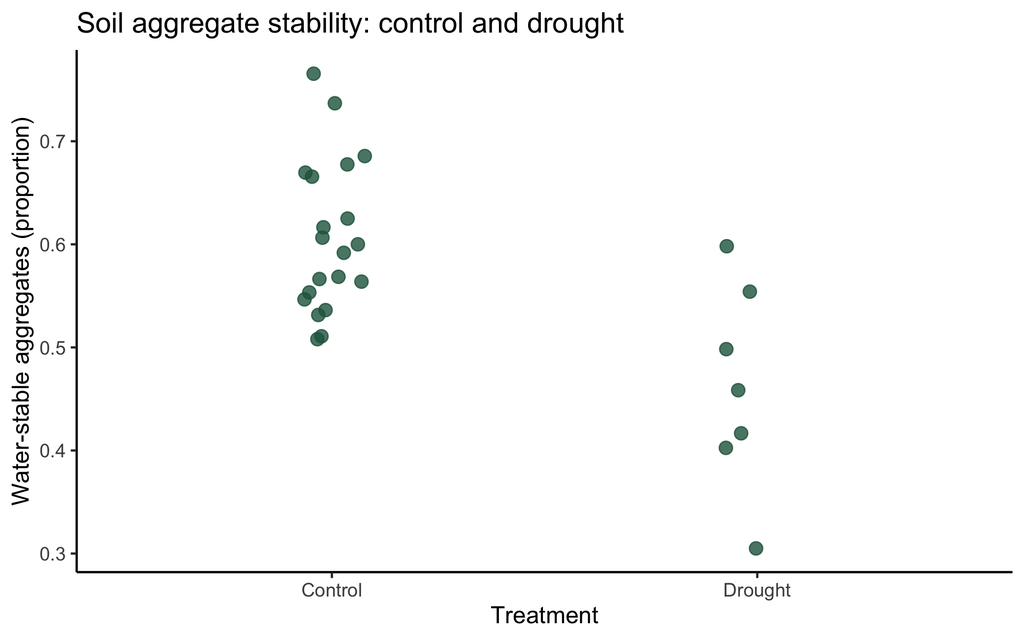

For the supplied file, the mean WSA is approximately **0.606 for control** and **0.462 for drought**. Drought minus control is approximately **−0.144** in proportion units, equivalent to **−14.4 percentage points**. This is a descriptive difference, not a relative percentage change. There is variation within both groups and some overlap.

Your figure’s title can differ. Check that the axes, treatment selection, and number of observations match. On Day 2, we will evaluate the difference and its uncertainty more formally.

I have a labelled figure and a descriptive interpretation linked to my prediction.

## 7. Save your work and check that it runs again

**Purpose:** leave a clear record that you or another student can reproduce.

Create an output folder and export the selected WSA dataset and figure:

```r
dir.create("outputs", showWarnings = FALSE)

write.csv(day1_wsa, "outputs/Day1_CT_D_WSA.csv", row.names = FALSE)
ggsave("outputs/Day1_CT_D_WSA.png", plot = wsa_plot,
       width = 7, height = 4.5, dpi = 300)

list.files("outputs")
```

**Do:** open the `outputs` folder and inspect both files. Save your script as `Day1_yourname.R` inside the project folder. At its end, add your prediction, the missing-value decision, and your interpretation as comments.

Now restart R using **Session → Restart R**. Run your script from its beginning. Restarting removes the current session’s objects; your saved files remain. If something works only before restarting, check whether the script is missing an earlier command.

**Check: what should be in my folder?**

- The original `MultiFactor_data.csv`, unchanged.
- Your saved `Day1_yourname.R` script.
- `outputs/Day1_CT_D_WSA.csv` with **27 rows** and the selected columns.
- `outputs/Day1_CT_D_WSA.png`, showing your figure.

A CSV does not preserve R’s factor type. If you later read the exported CSV into R, set the treatment order again if needed.

My script runs from a fresh session and creates both output files.

## 8. Show what you can do

**Core checkpoint · everyone**

Without copying an explanation from this page or an AI tool, explain to a partner or write in your script:

1. What does one point in your figure represent?
2. Why did we use `remark == "D"` instead of `D == 1`?
3. What does `na.rm = TRUE` do, and what does it not do?
4. What can you describe from today’s figure, and what still needs investigation?

Then adapt **one** command yourself: inspect another response, calculate a median instead of a mean, or change a plot label. Explain what you changed and why. Show your figure and script to the instructor or your partner.

**Extension · if you finish early**

Choose one task. Keep your original control–drought work intact.

- **Another response:** adapt the selection and figure for `PH`. Use an appropriate y-axis label and check missingness for `PH` before plotting. Compare the descriptive pattern with WSA.
- **Another treatment:** compare `CT` with salinity alone (`remark == "S"`). Check the group sizes and missing WSA values again. Use new object and output names.
- **A second syntax:** try the optional `dplyr` example in Part 4 and check whether it selects the same rows.

**Use AI as an explanation assistant**

Try your own explanation first. Then use this prompt with a course-approved tool:

> I am learning R using soil data. Explain each part of `control_data <- soil_data[soil_data$remark == "CT", ]`. Then give me a similar filtering exercise without its answer. Do not rewrite the whole analysis.

Run the command yourself, inspect the output, and check the explanation against your data. If an answer is unclear, ask about one part, such as `$`, `==`, or the comma. Keep a short note of what AI helped with and how you checked it. Use only course-approved data in your prompts.

I can explain my workflow and adapt a command without a worked solution.

## Help when something goes wrong

| What you see | First thing to check |
| --- | --- |
| `cannot open file` or `No such file` | Is the project open? Does `file.exists("MultiFactor_data.csv")` return `TRUE`? |
| `object ... not found` | Did you run the earlier assignment? Are spelling and capitalization identical? |
| `could not find function` | Is the function name correct? If it is from a package, did you run `library(...)`? |
| `there is no package called ...` | Install the package once, then load it. Ask for help if installation fails. |
| The Console shows `+` instead of `>` | A quote, bracket, or parenthesis may be unfinished. Press Esc, then inspect the command. |
| A calculation returns `NA` | Count missing values in the variables used; decide how the analysis should handle them. |
| The plot has no points | Check `nrow()` and `table()` on your selected dataset before changing the plot code. |

Errors are normal. Read the message, check the smallest relevant block, and ask for help with your code and the exact message.

## Reference and downloads

The course dataset is provided by Mohan Bi. For the research context and measurement methods, see [Bi et al. (2024), *Number and dissimilarity of global change factors influences soil properties and functions*](https://doi.org/10.1038/s41467-024-52511-2). The counts and reference results on this page refer specifically to the supplied **course CSV**.

Useful references: [RStudio Projects](https://docs.posit.co/ide/user/ide/get-started/), [R data import](https://stat.ethz.ch/R-manual/R-devel/library/utils/html/read.table.html), and [ggplot2 documentation](https://ggplot2.tidyverse.org/).

**Download a complete reference script after finishing**

Download `Day1_complete.R`. Compare it with your own script only after attempting the core tasks. Different correct scripts are possible.

Editable tutorial source and styling · Student files ·

Next: Day 2 uses the same control–drought comparison to explore hypothesis testing, effect sizes, and uncertainty.